# Booting python

Navigate to the class canvas homepage and click on the Online JupyterHub link. This will launch your own individual server in a web browser window. Poke around, make sure you can open a terminal to the (virtual) Linux machine.

If you are running python on your own machine (not recommened), make sure you have a good environment. Here is a copy of the .yaml file I use for a conda environment suitable for this class.

```
name: scratch
channels:
  - defaults
  - conda-forge
dependencies:
  - astropy
  - astropy-healpix
  - ipython
  - jupyter
  - jupyterlab
  - matplotlib
  - scipy
  - numpy
  - pandas
  - pyuvdata
  - pyyaml
  - yaml
```

## New notebook

To start a new notebook find the New command (File menu->New->Notebook), and select python 3. This should open a new Notebook. Make sure to save it with a name. You'll want a new notebook for every homework assignment and Lab.

## imports

Now import the libraries you will want to use, using `as` to shorten the names as desired.

```python
import numpy as np
import matplotlib
import matplotlib.pyplot as plt
import scipy
from scipy import stats

#this sets the size of the plot to something useful
plt.rcParams["figure.figsize"] = (15,10)
```

## Simple statistics

Okay, now for some simple statistics to make sure you're computing environment is setup and to practice a few commands we'll use over and over again.

First, let's draw a 100k points from a Gaussian distribution. In many areas of statistics a Gaussian distribution is called the 'Normal distribution'. So we'll dig into the `stats` package from `scipy` (see `import` lines above). Read up on the command to make sure you understand what it is doing.

```python
d = stats.norm.rvs(loc = 3.0, scale = .01, size = 100000)
```

Now let's plot a histogram of these points. *Make sure you understand what each of these commands is doing.*

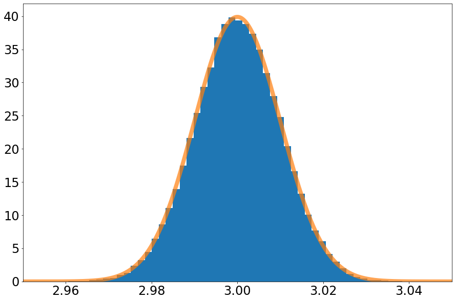

```python
fig, ax = plt.subplots(1, 1)
ax.hist(d,50, density=True)
plt.tick_params(labelsize = 24)
plt.xlim([2.95,3.05])
x = np.linspace(2.95,3.05,1000)
ax.plot(x,stats.norm.pdf(x,loc = 3., scale = 0.01),linewidth = 8,alpha = 0.7)
plt.show()
```

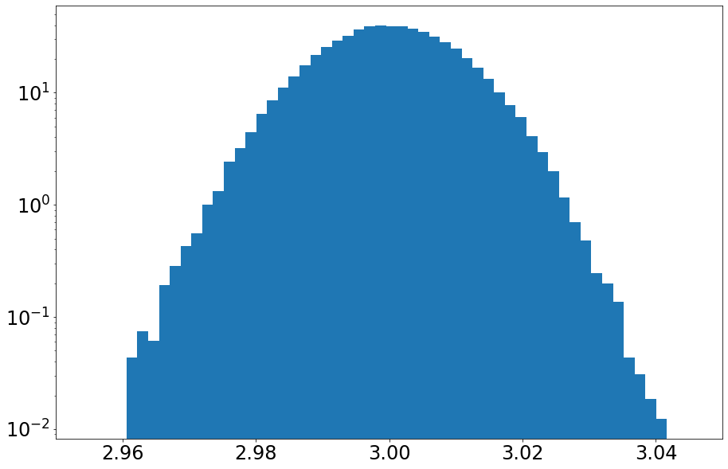

```python
ax = plt.hist(d,50, density=True)
plt.yscale('log')
plt.tick_params(labelsize = 24)
plt.xlim([2.95,3.05])
plt.show()
```

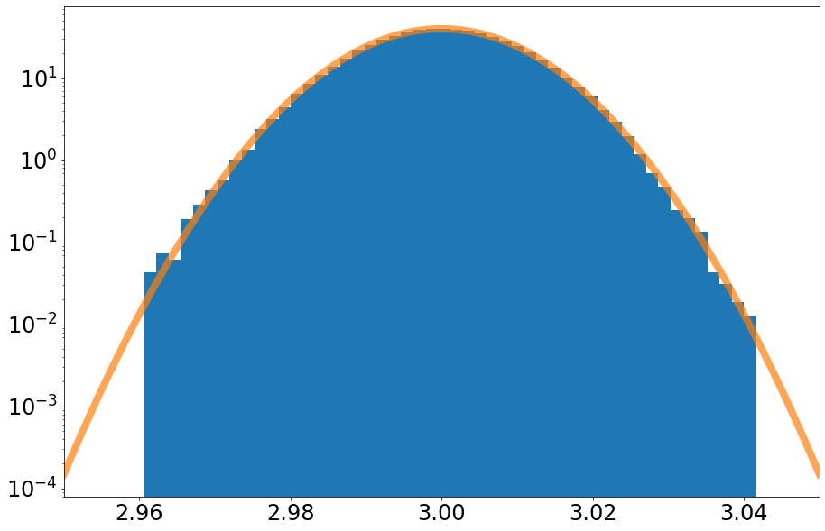

```python
fig, ax = plt.subplots(1, 1)
ax.hist(d,50, density=True)
plt.yscale('log')
plt.tick_params(labelsize = 24)
plt.xlim([2.95,3.05])
x = np.linspace(2.95,3.05,1000)
ax.plot(x,stats.norm.pdf(x,loc = 3., scale = 0.01),linewidth = 8,alpha = 0.7)
plt.show()
```